*Assignment - 1 Manasa Pullabhatla - 811284922*

*Data Source - Kaggle* *https://www.kaggle.com/datasets/surajjha101/cuisine-rating*

#Loading Libraries

```r
library("ISLR")
library("caret")
```

```r
library("ggplot2")
library("esquisse")
```

##Import the dataset into R #Loading Data

```r
res_data <- read.csv("Cuisine_rating.csv")
```

#Loading the initial few rows of data

```r
head(res_data,n=10)
```

```
##    User.ID Area.code           Location Gender  YOB Marital.Status     Activity
## 1        1       153 Upper East Side,NY Female 2006         Single Professional
## 2        2       123      St. George,NY Female 1991        Married      Student
## 3        3       122 Upper West Side,NY   Male 1977         Single      Student
## 4        4       153 Upper East Side,NY Female 1956        Married Professional
## 5        5       129    Central Park,NY   Male 1997         Single      Student
## 6        6       111     China Town, NY   Male 1995         Single      Student
## 7        7       111     China Town, NY Female 1977        Married Professional
## 8        8       153 Upper East Side,NY Female 2003         Single Professional
## 9        9       107       Riverdale,NY   Male 1965         Single      Student
## 10      10       129    Central Park,NY   Male 1995         Single      Student
##    Budget Cuisines  Alcohol   Smoker Food.Rating Service.Rating Overall.Rating
## 1       3 Japanese    Never    Never           5              4            4.5
## 2       3   Indian    Never Socially           1              1            1.0
## 3       5  Seafood    Often    Often           5              5            5.0
```

[output cut: 18 more lines]

```r
#Alternatively tail can be used to print the last records in a dataset
tail(res_data,n=10)
```

```
##     User.ID Area.code           Location Gender  YOB Marital.Status
## 191     191       185     Cedar Hill, NY   Male 1960        Married
## 192     192       178     China Town, NY   Male 1969       Divorced
## 193     193       105      St. George,NY   Male 2000         Single
## 194     194       103       Riverdale,NY Female 1985        Married
## 195     195       107     China Town, NY   Male 1974        Married
## 196     196       175      St. George,NY Female 1982         Single
## 197     197       170 Upper West Side,NY Female 2000        Married
## 198     198       160      St. George,NY Female 2006         Single
## 199     199       130      St. George,NY   Male 2002        Married
## 200     200       140 Upper East Side,NY   Male 2005        Married
##         Activity Budget Cuisines  Alcohol   Smoker Food.Rating Service.Rating
## 191 Professional      4   Indian Socially Socially           2              5
## 192 Professional      3   French    Never    Often           3              1
## 193 Professional      5   French    Never    Often           5              5
```

[output cut: 18 more lines]

#Print out descriptive statistics for a selection of quantitative and categorical variables.

```r
str(res_data)
```

```
## 'data.frame':    200 obs. of  15 variables:
##  $ User.ID       : int  1 2 3 4 5 6 7 8 9 10 ...
##  $ Area.code     : int  153 123 122 153 129 111 111 153 107 129 ...
##  $ Location      : chr  "Upper East Side,NY" "St. George,NY" "Upper West Side,NY" "Upper East Side,NY" ...
##  $ Gender        : chr  "Female" "Female" "Male" "Female" ...
##  $ YOB           : int  2006 1991 1977 1956 1997 1995 1977 2003 1965 1995 ...
##  $ Marital.Status: chr  "Single" "Married" "Single" "Married" ...
##  $ Activity      : chr  "Professional" "Student" "Student" "Professional" ...
##  $ Budget        : int  3 3 5 5 4 5 5 3 5 4 ...
##  $ Cuisines      : chr  "Japanese" "Indian" "Seafood" "Japanese" ...
##  $ Alcohol       : chr  "Never" "Never" "Often" "Never" ...
##  $ Smoker        : chr  "Never" "Socially" "Often" "Socially" ...
##  $ Food.Rating   : int  5 1 5 3 2 5 1 5 3 5 ...
##  $ Service.Rating: int  4 1 5 1 4 1 4 2 3 2 ...
##  $ Overall.Rating: num  4.5 1 5 2 3 3 2.5 3.5 3 3.5 ...
##  $ Often.A.S     : chr  "No" "No" "Yes" "No" ...
```

*Structure (str) is commonly used to understand the data types and the count of rows and attributes in a data set.*

#Summary of the data

```r
summary(res_data)
```

```
##     User.ID         Area.code       Location            Gender
##  Min.   :  1.00   Min.   :101.0   Length:200         Length:200
##  1st Qu.: 50.75   1st Qu.:123.0   Class :character   Class :character
##  Median :100.50   Median :135.0   Mode  :character   Mode  :character
##  Mean   :100.50   Mean   :141.1
##  3rd Qu.:150.25   3rd Qu.:158.0
##  Max.   :200.00   Max.   :199.0
##       YOB       Marital.Status       Activity             Budget
##  Min.   :1955   Length:200         Length:200         Min.   :1.000
##  1st Qu.:1971   Class :character   Class :character   1st Qu.:3.000
##  Median :1987   Mode  :character   Mode  :character   Median :4.000
##  Mean   :1985                                         Mean   :3.815
##  3rd Qu.:2000                                         3rd Qu.:5.000
##  Max.   :2009                                         Max.   :5.000
##    Cuisines           Alcohol             Smoker           Food.Rating
##  Length:200         Length:200         Length:200         Min.   :1.00
##  Class :character   Class :character   Class :character   1st Qu.:2.00
##  Mode  :character   Mode  :character   Mode  :character   Median :3.00
##                                                           Mean   :3.22
##                                                           3rd Qu.:5.00
##                                                           Max.   :5.00
##  Service.Rating Overall.Rating   Often.A.S
##  Min.   :1.00   Min.   :1.000   Length:200
##  1st Qu.:2.00   1st Qu.:2.500   Class :character
##  Median :3.00   Median :3.000   Mode  :character
##  Mean   :3.23   Mean   :3.225
##  3rd Qu.:5.00   3rd Qu.:4.000
##  Max.   :5.00   Max.   :5.000
```

*Gives a comprehensive understanding of the data, for example - mean, median, 1st quartile, 3rd quartile etc…*

#Transform at least one variable

```r
res_data$Overall.Rating <- as.integer(res_data$Overall.Rating)

is.integer(res_data$Overall.Rating)
```

```
## [1] TRUE
```

*The category “overall rating” was previously in the form of double (decimal) which then converted into a integer (whole number). At the end we verified the conversion is right by using is.integer function as we got the result as TRUE, it is confirmed that the conversion has been done.*

#Plot scatterplot

#In order to plot a scatter plot we are using the default cars dataset because this can be used to explain the relationship between speed and distance in a efficient way

```r
scat_data <- cars
```

#Plot

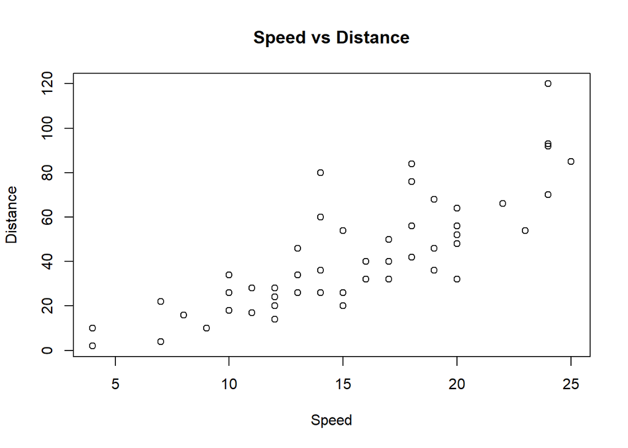

```r
plot(scat_data$speed, scat_data$dist,main="Speed vs Distance",xlab="Speed",ylab="Distance")
```

*If a car travels at higher speed it is going to cover more distance for example when the car is travelling at 20 - 25 miles an hour the distance covered is significantly higher, else wise when we check the distance covered when the car is travelling at 5 miles an hour it is very less.*

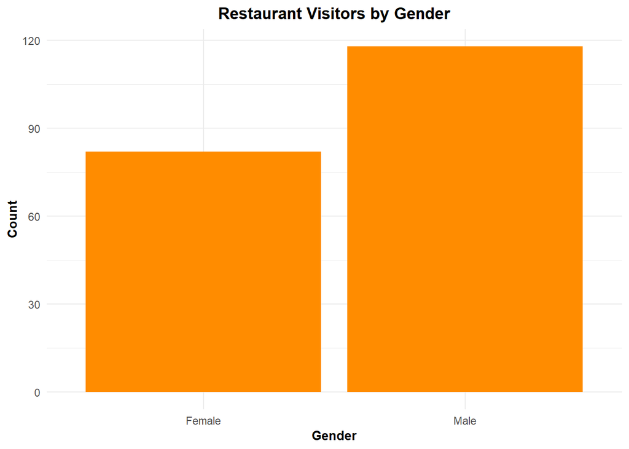

```r
#esquisser() #Package used to build the plot
ggplot(res_data) +
  aes(x = Gender) +
  geom_bar(fill = "#FF8C00") +
  labs(
    x = "Gender",
    y = "Count",
    title = "Restaurant Visitors by Gender"
  ) +
  theme_minimal() +
  theme(
    plot.title = element_text(face = "bold",
    hjust = 0.5),
    axis.title.y = element_text(size = 10L,
    face = "bold"),
    axis.title.x = element_text(size = 10L,
    face = "bold")
  )
```

#Table

```r
table(res_data$Gender)
```

```
##
## Female   Male
##     82    118
```

*From the above bar graph and table, we can conclude that male prefer visiting restaurants in higher volumes when compared to that with the females.*